# Pessoas e medidas

Lista avaliativa – Probabilidade e Estatística – 2022.1

fnaufel

(v. 10/07/2022)

# Instruções

## Fase de coleta de dados e amostragem

- Siga cuidadosamente as instruções em *coleta de dados* e envie os arquivos `.csv` no Moodle.

## Fase de resolução

- Aguarde que o professor envie a você os arquivos `.csv` com os dados que você vai usar na resolução das questões.
- Clique o botão `Code`, no início desta página, para baixar o arquivo Rmd deste documento.
- Edite o arquivo Rmd para resolver as questões com os dados atribuídos a você.
- Escreva o máximo possível sobre o seu raciocínio. Justifique suas respostas.
- Teste suas respostas. Tudo deve estar executando sem erros.
- Envie no Moodle:
  1. O arquivo Rmd com as suas resoluções e
  2. Um vídeo de até $5$ minutos explicando as suas resoluções.
- Bom trabalho.

# Ambiente

- Para gerar um arquivo HTML a partir deste documento, você precisa dos seguintes pacotes do R:
  - `conflicted`
  - `devtools`
  - `fnaufelRmd`
  - `kableExtra`
  - `knitr`
  - `latex2exp`
  - `sessioninfo`
  - `summarytools`
  - `tidyverse`
- Execute o seguinte código para instalar os pacotes que estão faltando no seu ambiente:

  ```r
  if (!require('devtools'))
    install.packages('devtools')

  if (!require('fnaufelRmd'))
    devtools::install_github("fnaufel/fnaufelRmd")

  pacotes <- c(
    'conflicted',
    'kableExtra',
    'knitr',
    'latex2exp',
    'sessioninfo',
    'summarytools',
    'tidyverse'
  )

  instalar_se_preciso <- function(x) {

    if (!require(x, character.only = TRUE))
      install.packages(x)

  }

  invisible(sapply(pacotes, instalar_se_preciso))
  ```

- Se houver erro na instalação, entre em contato com o professor pelo Telegram, enviando todas as mensagens emitidas quando você executou os comandos.

# 1 Coleta de dados

## 1.1 Sinistrismo

1. Escolha $5$ pessoas dentre seus familiares e seus amigos.
2. Peça a cada uma das pessoas para preencher o questionário abaixo.
3. Preencha você também o questionário abaixo com as suas respostas.

#### **QUESTIONÁRIO SOBRE PREFERÊNCIA DE MÃO**

   Por favor, indique qual mão você usaria para cada atividade abaixo, do seguinte modo:
   - Se você usaria *preferencialmente* uma das mãos, mas poderia usar — ou ocasionalmente usa — a outra mão, com resultados inferiores, então coloque “`+`” (um sinal de mais) na coluna da mão preferida.
   - Se você *sempre* usaria uma das mãos, e nunca a outra, então coloque “`+ +`” (*dois* sinais de mais) na coluna da mão usada.
   - Se você for *indiferente* quanto à mão usada, então coloque um “`+`” (sinal de mais) *em cada coluna*.

   | ATIVIDADE | ESQUERDA | DIREITA |
   | --- | --- | --- |
   | Escrever |  |  |
   | Desenhar |  |  |
   | Arremessar uma pedra |  |  |
   | Cortar papel com uma tesoura |  |  |
   | Escovar os dentes (com escova manual) |  |  |
   | Passar manteiga no pão com uma faca |  |  |
   | Tomar sopa com uma colher |  |  |
   | Varrer o chão (mão na parte de cima da vassoura) |  |  |
   | Riscar um fósforo (mão que segura o fósforo) |  |  |
   | Abrir uma caixa de sapatos (mão que segura a tampa) |  |  |

4. Gere o arquivo `sinistrismo.csv` com os resultados.

   O arquivo terá $7$ linhas (a primeira delas contendo os nomes das colunas) e duas colunas:
   - `sexo`: `M` ou `F`.
   - `nota`: um valor de ponto flutuante entre $-1$ e $1$ (inclusive) com $3$ casas decimais, calculado para cada pessoa do seguinte modo:
     - $E = {}$ quantidade de “`+`” na coluna `Esquerda` do questionário preenchido.
     - $D = {}$ quantidade de “`+`” na coluna `Direita` do questionário preenchido.
     - `nota` $\displaystyle {}= \frac{E - D}{E + D}$
5. Envie o arquivo no Moodle.

## 1.2 Razão altura-mão

1. Escolha $5$ pessoas dentre seus familiares e seus amigos.
2. Registre, para cada pessoa,
   - O sexo,
   - A altura em centímetros, com $1$ casa decimal,
   - A distância, em centímetros, com $1$ casa decimal, entre a ponta do dedo mínimo e a ponta do polegar (ambos da mão esquerda), com a mão mais aberta possível — como se a pessoa fosse tocar, ao mesmo tempo, só com a mão esquerda, duas teclas de um piano, uma muito afastada da outra.
3. Registre os mesmos dados para você mesmo.
4. Gere o arquivo `razao.csv` com os resultados.

   O arquivo terá $7$ linhas (a primeira delas contendo os nomes das colunas) e $4$ colunas:
   - `sexo`: `M` ou `F`.
   - `altura`: um valor de ponto flutuante com $1$ casa decimal.
   - `mao`: um valor de ponto flutuante com $1$ casa decimal.
   - `razao`: um valor de ponto flutuante com $1$ casa decimal, com a razão $\displaystyle \frac{\texttt{altura}}{\texttt{mao}}$.
5. Envie o arquivo no Moodle.

# 2 Questões

## 2.1 Sinistrismo

1. Leia o arquivo `sinistrismo-amostra.csv` que você recebeu, gerando uma *tibble*.
2. Faça uma breve análise exploratória:
   1. Quantos elementos tem sua amostra?
   2. Quais as proporções de homens e mulheres?
   3. Quais as estatísticas globais relativas a `nota`?
   4. Quais as estatísticas por sexo relativas a `nota`?
   5. Faça gráficos de `nota` (globais e por sexo). Escolha os tipos de gráfico mais adequados para a situação. Comente os resultados.
3. Pesquise na internet: qual é a proporção de canhotos na população em geral?
4. Considere como canhota qualquer pessoa da sua amostra com `nota` ${}> 0{,}5$.
5. Construa um intervalo de confiança para a proporção de canhotos na população, com base na sua amostra. Use nível de confiança de $95\%$.
6. A proporção de canhotos na população em geral (que você pesquisou no item 3) está dentro do intervalo de confiança que você construiu? O que isto significa?
7. Teste a seguinte hipótese: a média das notas dos homens é igual à média das notas das mulheres. Use $\alpha = 0{,}05$. Comente o resultado.

## 2.2 Razão altura-mão

1. Leia o arquivo `razao-amostra.csv` que você recebeu, gerando uma *tibble*.
2. Faça uma breve análise exploratória:
   1. Quantos elementos tem sua amostra?
   2. Quais as proporções de homens e mulheres?
   3. Quais as estatísticas globais relativas a `altura`, `mao`, e `razao`?
   4. Quais as estatísticas por sexo relativas a `altura`, `mao`, e `razao`?
   5. Faça gráficos de `altura`, `mao`, e `razao` (globais e por sexo). Escolha os tipos de gráfico mais adequados para a situação. Comente os resultados.
3. Teste a seguinte hipótese: `razao` é, em média, maior para os homens do que para as mulheres. Use $\alpha = 0{,}05$. Comente o resultado.
4. Construa um intervalo de confiança para a diferença das alturas médias entre homens e mulheres. Use nível de confiança de $95\%$.
5. Qual é a correlação entre `mao` e `altura`, sem levar em conta o sexo?
6. Qual é a correlação entre `mao` e `altura`, levando em conta o sexo?

# 3 Resolução

## 3.1 Sinistrismo

1. 1. A amostra tem 15 elementos
   2. 53{,}33% da amostra é homem e 46{,}67% é mulher
1. Média: -0{,}66  
   Mediana: -0{,}79  
   Moda: -0{,}89  
   Desvio padrão: 0{,}44
2. Homens:  
   Média: -0{,}84  
   Mediana: -0{,}88  
   Moda: -0{,}95  
   Desvio padrão: 0{,}18  
   Mulheres:  
   Média: -0{,}44  
   Mediana: -0{,}73  
   Moda: -0{,}82  
   Desvio padrão: 0{,}56

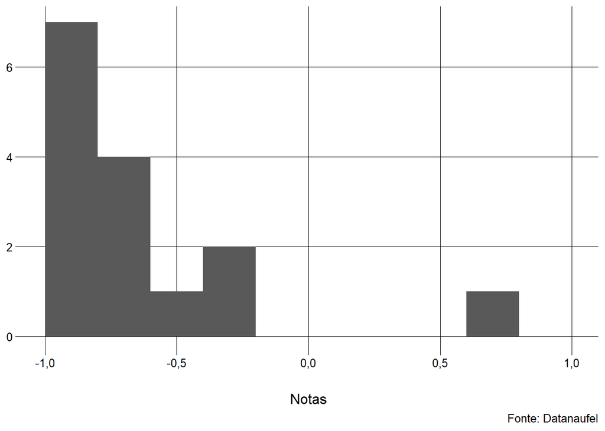

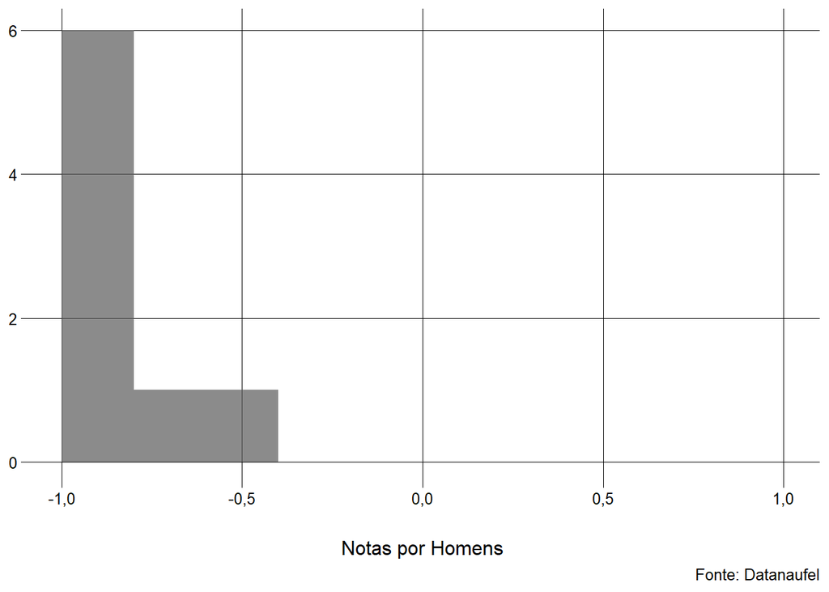

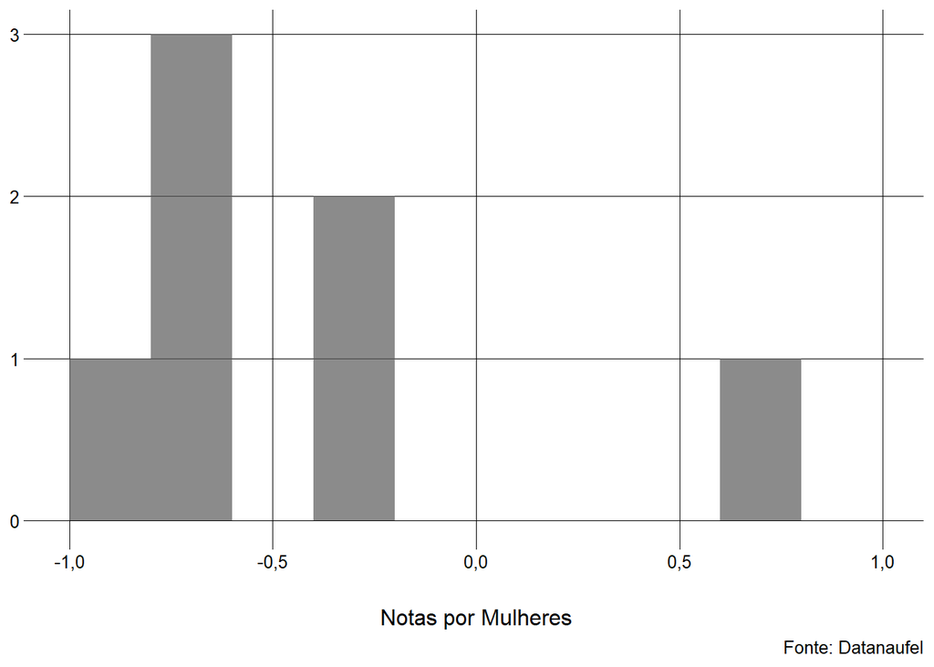

A maior parte das notas esta abaixo de 0. Todas as notas de homens estão abaixo de 0. A tendencia é que as notas se distanciem de 0.

1. “Pouco mais de 10% da população mundial é canhota”

```
## [1] 0,00168643 0,31948457
## attr(,"conf.level")
## [1] 0,95
```

1. O valor encontrado na pesquisa esta dentro do intervalo construido. Isto significa que temos uma boa amostra.

```
##
##  1-sample proportions test without continuity correction
##
## data:  mediaHomem + 1 out of qtdSinistrismo, null probability mediaMulher + 1
## X-squared = 18,522, df = 1, p-value = 0,0000168
## alternative hypothesis: true p is not equal to 0,5617143
## 95 percent confidence interval:
##  0,0003882914 0,2199878940
## sample estimates:
##          p
## 0,01035833
```

```
## [1] 0,155375
```

## 3.2 Razao

| sexo | altura | mao | razao |
| --- | --- | --- | --- |
| M | 177,0 | 22,0 | 8,000000 |
| F | 160,0 | 11,0 | 14,000000 |
| M | 178,0 | 24,5 | 7,000000 |
| M | 170,0 | 22,3 | 7,600000 |
| M | 175,0 | 21,5 | 8,100000 |
| M | 97,8 | 12,7 | 7,700000 |
| F | 158,5 | 20,5 | 7,731707 |
| F | 172,0 | 20,0 | 8,600000 |
| F | 158,0 | 13,5 | 11,700000 |
| M | 160,0 | 18,1 | 8,800000 |

[output cut: 5 more lines]

1. 1. A amostra tem 15 elementos
   2. 66{,}67% da amostra é homem e 33{,}33% é mulher

   3. |  | Altura | Mao | Razao |
      | --- | --- | --- | --- |
      | Médias | 165{,}13 | 19{,}21 | 8{,}78 |
      | Mediana | 172 | 20{,}50 | 8{,}40 |
      | Moda | 175 | 21 | 8{,}10 |
      | Desvio padrão | 20{,}82 | 3{,}84 | 1{,}79 |

   4. | Homens: | Altura | Mao | Razao |
      | --- | --- | --- | --- |
      | Médias | 167{,}32 | 20{,}39 | 8{,}16 |
      | Mediana | 176 | 21{,}10 | 8{,}25 |
      | Moda | 175{,}60 | 21{,}65 | 8{,}25 |
      | Desvio padrão | 25{,}29 | 3{,}16 | 0{,}62 |

      | Mulheres: | Altura | Mao | Razao |
      | --- | --- | --- | --- |
      | Médias | 160{,}76 | 16{,}86 | 10{,}01 |
      | Mediana | 158{,}50 | 19{,}30 | 8{,}60 |
      | Moda | 159 | 19{,}90 | 8{,}17 |
      | Desvio padrão | 6{,}51 | 4{,}32 | 2{,}74 |

[figure not shown]

[figure not shown]

[figure not shown]

Pela reta de regressão, podemos relacionar o tamanho da mao e a altura, quanto maior sendo a altura, maior será a mão

```
##
##  One Sample t-test
##
## data:  razoesHomem
## t = -9,466, df = 9, p-value = 1
## alternative hypothesis: true mean is greater than 10,00634
## 95 percent confidence interval:
##  7,802452      Inf
## sample estimates:
## mean of x
##      8,16
```

Não Existem evidencias para rejeitar a hipotese de nulidade, uma vez que o valor de p é maior que 0,5

[output not shown]

1. Correlação entre altura e mão: 0{,}66
2. Correlação entre altura e mão de homens: 0{,}89  
   Correlação entre altura e mão de mulheres: 0{,}24